# Project Report

Andrew Liawan, Ethan Nathanael, Kyle Nelwan

11/04/2022

## DATASET SETUPS

```r
df <- read.csv("hour.csv")
df<- subset(df, select = -c(instant,cnt,dteday))
```

## INITIAL ASSESSMENT (Casual)

```r
model.cas <- lm(casual ~. - registered, data = df)
summary(model.cas)
```

```
##
## Call:
## lm(formula = casual ~ . - registered, data = df)
##
## Residuals:
##     Min      1Q  Median      3Q     Max
## -95.644 -20.637  -3.665  13.641 272.152
##
## Coefficients:
##              Estimate Std. Error t value Pr(>|t|)
## (Intercept)  18.97181    1.81005  10.481  < 2e-16 ***
## season        1.64953    0.46649   3.536 0.000407 ***
## yr           10.27258    0.55517  18.504  < 2e-16 ***
## mnth         -0.03204    0.14547  -0.220 0.825676
## hr            1.20460    0.04230  28.478  < 2e-16 ***
## holiday     -11.65178    1.71703  -6.786 1.19e-11 ***
## weekday       0.83061    0.13868   5.989 2.15e-09 ***
## workingday  -35.27126    0.61446 -57.402  < 2e-16 ***
## weathersit    1.99824    0.48850   4.091 4.32e-05 ***
## temp         52.62079    9.47914   5.551 2.88e-08 ***
## atemp        62.92738   10.64870   5.909 3.50e-09 ***
## hum         -69.94589    1.76687 -39.587  < 2e-16 ***
## windspeed     2.99422    2.46960   1.212 0.225365
## ---
## Signif. codes:  0 '***' 0.001 '**' 0.01 '*' 0.05 '.' 0.1 ' ' 1
##
## Residual standard error: 36.38 on 17366 degrees of freedom
## Multiple R-squared:  0.4559, Adjusted R-squared:  0.4555
## F-statistic:  1212 on 12 and 17366 DF,  p-value: < 2.2e-16
```

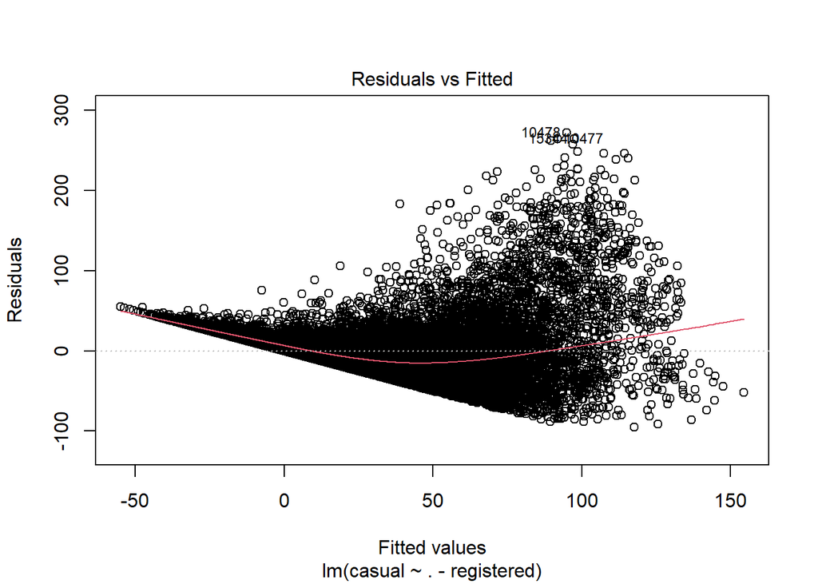

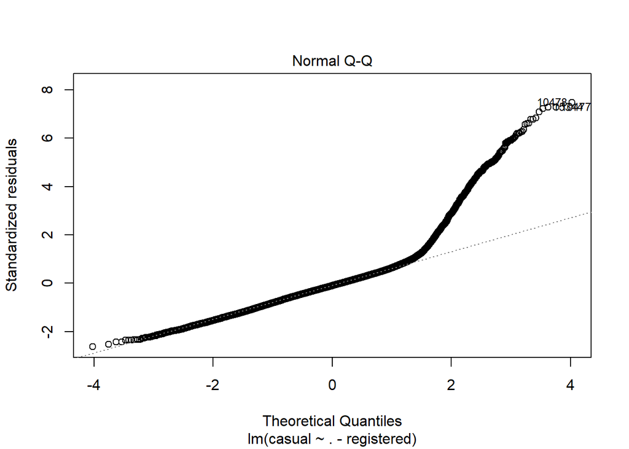

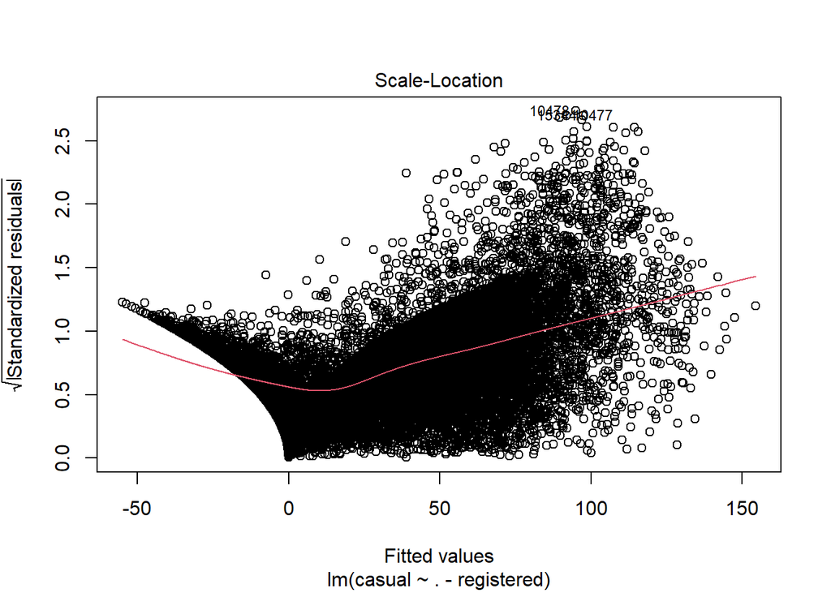

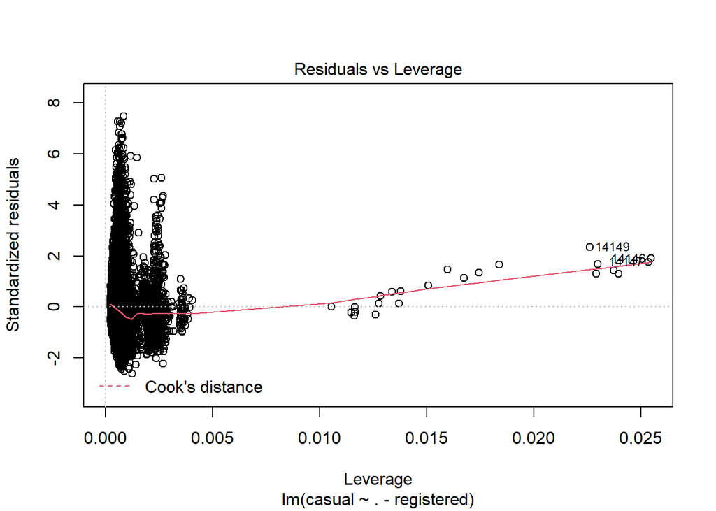

```r
plot(model.cas)
```

First, we regress the number of casual users with all the available variables. At first glance, we could see that most of variables are highly significant. However, notice that our adjusted R-squared is less than 0.5. Therefore, even though our model is significant, it can only explain less than half of the data.

The residuals vs fitted diagnostic plot has a clear pattern. Our data set seems to have a quadratic relationship. The Normal Q-Q plot shows that our model is highly right skewed. This is a huge problem for us. Notice that those rightly skewed data have a very large value of standardized residuals. Hence, the this original linear model is flawed. The residuals vs leverage plot tells us that none of our data are influential points but have high residuals as stated before.

## INITIAL ASSESSMENT (Registered)

```r
model.reg <- lm(registered ~. - casual, data = df)
summary(model.reg)
```

```
##
## Call:
## lm(formula = registered ~ . - casual, data = df)
##
## Residuals:
##     Min      1Q  Median      3Q     Max
## -305.33  -78.74  -25.16   46.54  620.24
##
## Coefficients:
##               Estimate Std. Error t value Pr(>|t|)
## (Intercept)  -44.72910    6.14037  -7.284 3.37e-13 ***
## season        18.24981    1.58249  11.532  < 2e-16 ***
## yr            70.81457    1.88333  37.601  < 2e-16 ***
## mnth           0.02339    0.49348   0.047  0.96219
## hr             6.46600    0.14349  45.061  < 2e-16 ***
## holiday      -10.22744    5.82481  -1.756  0.07913 .
## weekday        1.04774    0.47045   2.227  0.02595 *
## workingday    39.21048    2.08447  18.811  < 2e-16 ***
## weathersit    -5.43034    1.65719  -3.277  0.00105 **
## temp          25.52899   32.15683   0.794  0.42727
## atemp        170.22971   36.12441   4.712 2.47e-06 ***
## hum         -128.23879    5.99389 -21.395  < 2e-16 ***
## windspeed     38.57100    8.37783   4.604 4.18e-06 ***
## ---
## Signif. codes:  0 '***' 0.001 '**' 0.01 '*' 0.05 '.' 0.1 ' ' 1
##
## Residual standard error: 123.4 on 17366 degrees of freedom
## Multiple R-squared:  0.3355, Adjusted R-squared:  0.335
## F-statistic: 730.6 on 12 and 17366 DF,  p-value: < 2.2e-16
```

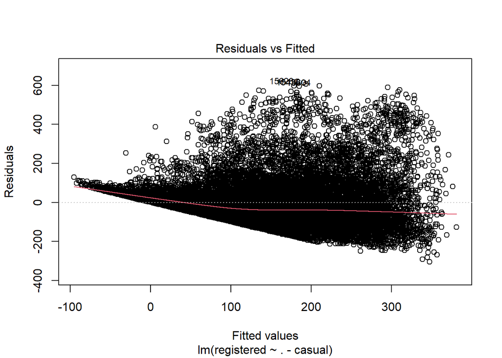

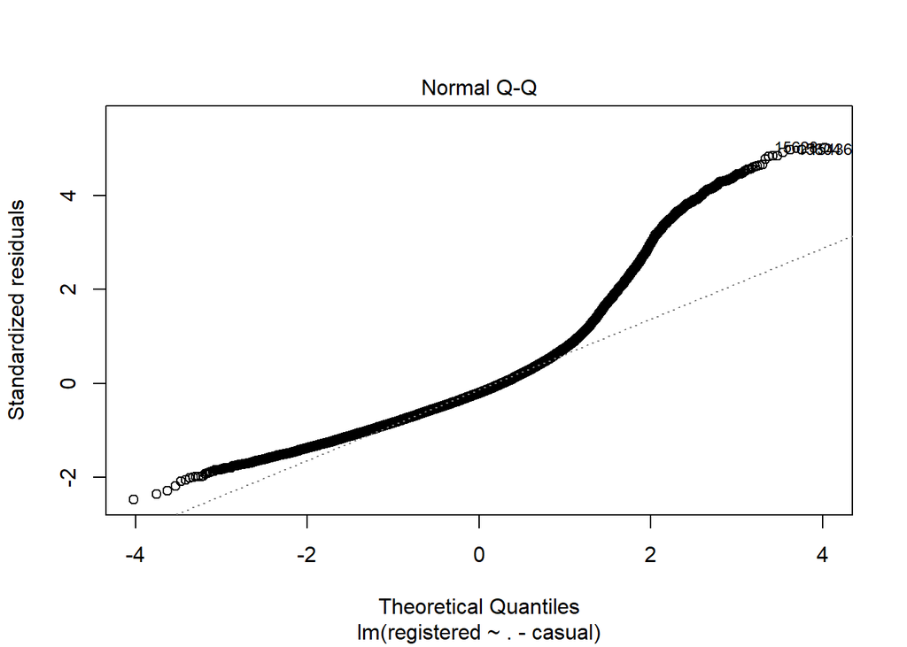

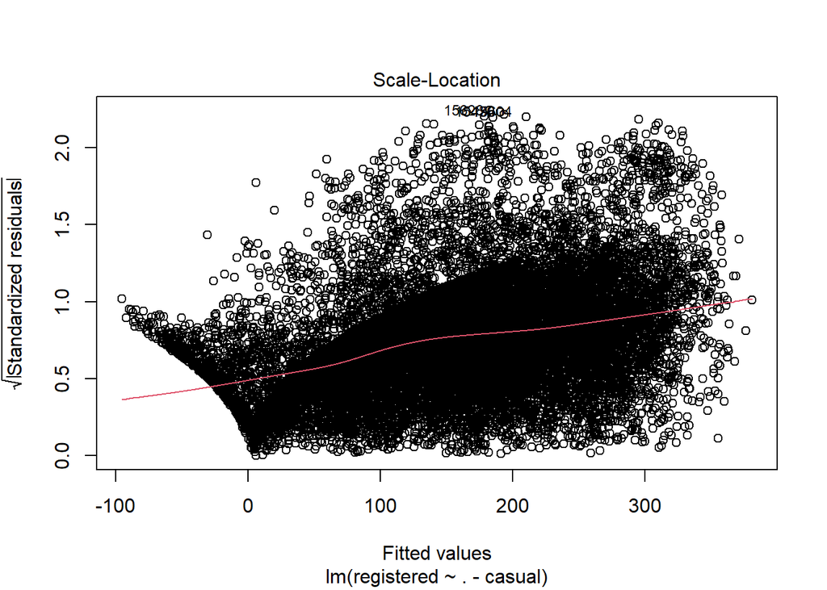

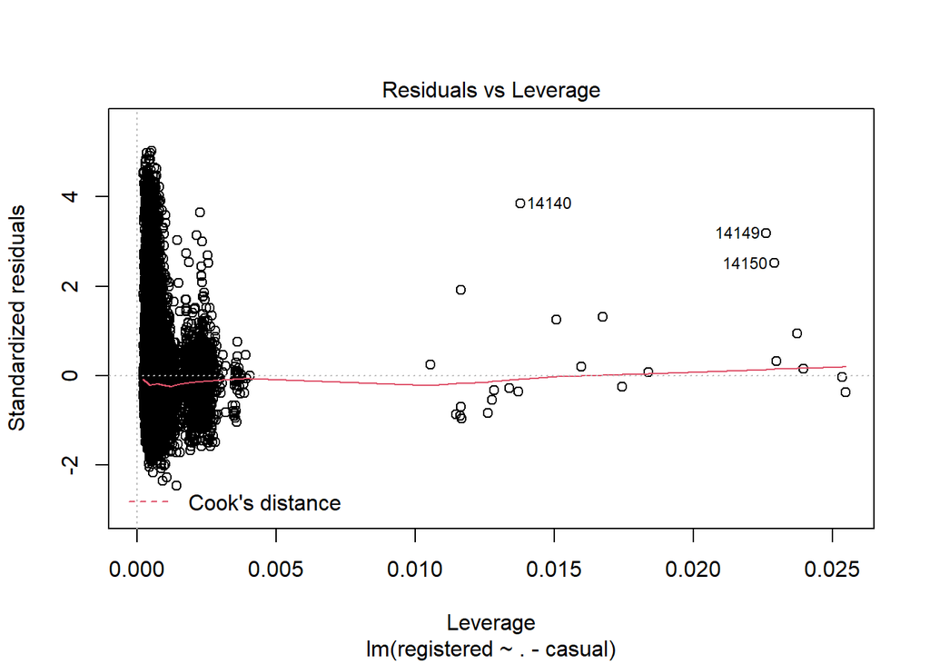

```r
plot(model.reg)
```

On further inspection, our data may have a quadratic or a decaying relationship. This is shown in the residuals vs fitted plot.  
The Normal Q-Q plot shows that our data set have a light left tail and a heavy right tail. Hence, we can conclude that our data set is rightly skewed. Note that a lot of our data are beyond the 2 standardized residuals range. Therefore, we have a problem with our current linear model.

Similar with the previous model, this model does not have any influence points but have high residuals value.

## MULTICOLLINEARITY ASSESSMENT (Casual)

```r
VIF(model.cas)
```

```
##     season         yr       mnth         hr    holiday    weekday workingday
##   3.500344   1.011587   3.285102   1.122967   1.081564   1.015767   1.073735
## weathersit       temp      atemp        hum  windspeed
##   1.280636  43.737818  43.964035   1.525502   1.198389
```

```r
modelwotemp <- lm(casual ~.-temp - registered, data = df)
VIF(modelwotemp)
```

```
##     season         yr       mnth         hr    holiday    weekday workingday
##   3.499576   1.011470   3.285051   1.122679   1.080688   1.013937   1.073458
## weathersit      atemp        hum  windspeed
##   1.279314   1.171256   1.520035   1.141924
```

```r
modelwoatemp <- lm(casual ~.-atemp - registered, data = df)
VIF(modelwoatemp)
```

```
##     season         yr       mnth         hr    holiday    weekday workingday
##   3.497427   1.011572   3.284558   1.121382   1.080560   1.013850   1.073672
## weathersit       temp        hum  windspeed
##   1.278094   1.165229   1.520979   1.140001
```

```r
modelwoseason <- lm(casual ~.-season - registered, data = df)
VIF(modelwoseason)
```

```
##         yr       mnth         hr    holiday    weekday workingday weathersit
##   1.011406   1.090735   1.122369   1.080214   1.015373   1.073696   1.280136
##       temp      atemp        hum  windspeed
##  43.728229  43.927403   1.523823   1.195957
```

```r
modelwomnth <- lm(casual ~.-mnth - registered, data = df)
VIF(modelwomnth)
```

```
##     season         yr         hr    holiday    weekday workingday weathersit
##   1.162201   1.011524   1.121696   1.079505   1.014882   1.073598   1.280550
##       temp      atemp        hum  windspeed
##  43.737128  43.956742   1.519730   1.198358
```

We can see that there exist a high VIF value between temp and atemp. This make sense since both variable indicates the value of the hourly temperature. Therefore, we need to remove one of those variables. Also, there seems to be a relatively high VIF value between season and month. This make sense since certain months always have the same season. Hence, we remove season from the model as the mnth variable give us more insight into the data as there is more available inputs.

As shown above, the VIF values got better (closer to 1), when one of the correlated variable is removed (ex. VIF of atemp got better when temp is removed, etc.)

Also should be noted that the VIF values for casual and registered models are the same, since both models use the same set of explanatory variables.

## BOX-COX TRANSFORMATION

### Linear, Casual, atemp

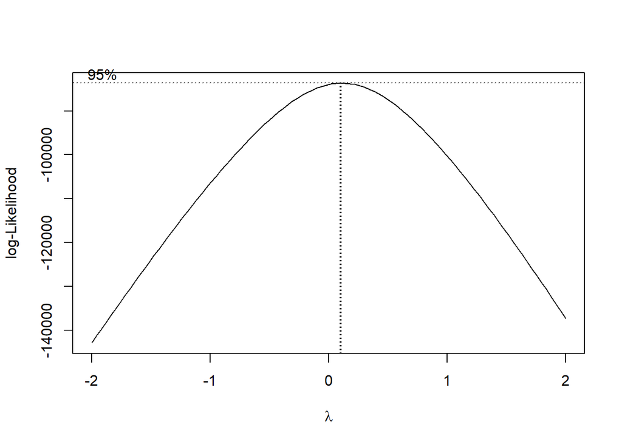

```r
x.la <- subset(df, select = - c(season,temp))
x.la$casual <- x.la$casual+1
x.la$registered <- x.la$registered+1

bc.lca<-boxcox(casual ~. - registered,data = x.la)
```

```r
lambda.lca <- bc.lca$x[which.max(bc.lca$y)]
model.lca <- lm(((casual^lambda.lca-1)/lambda.lca) ~ . - registered, data = x.la)

summary(model.lca)
```

```
##
## Call:
## lm(formula = ((casual^lambda.lca - 1)/lambda.lca) ~ . - registered,
##     data = x.la)
##
## Residuals:
##     Min      1Q  Median      3Q     Max
## -4.4609 -0.8284  0.0697  0.8727  4.1298
##
## Coefficients:
##              Estimate Std. Error t value Pr(>|t|)
## (Intercept)  1.291501   0.059429  21.732  < 2e-16 ***
## yr           0.301281   0.018747  16.071  < 2e-16 ***
## mnth         0.034992   0.002831  12.362  < 2e-16 ***
## hr           0.093654   0.001428  65.584  < 2e-16 ***
## holiday     -0.309020   0.057931  -5.334 9.71e-08 ***
## weekday      0.015430   0.004679   3.298 0.000976 ***
## workingday  -0.960457   0.020749 -46.289  < 2e-16 ***
## weathersit   0.015417   0.016487   0.935 0.349747
## atemp        5.668519   0.056580 100.185  < 2e-16 ***
## hum         -2.638255   0.059535 -44.314  < 2e-16 ***
## windspeed    0.316069   0.081343   3.886 0.000102 ***
## ---
## Signif. codes:  0 '***' 0.001 '**' 0.01 '*' 0.05 '.' 0.1 ' ' 1
##
## Residual standard error: 1.229 on 17368 degrees of freedom
## Multiple R-squared:  0.6015, Adjusted R-squared:  0.6013
## F-statistic:  2622 on 10 and 17368 DF,  p-value: < 2.2e-16
```

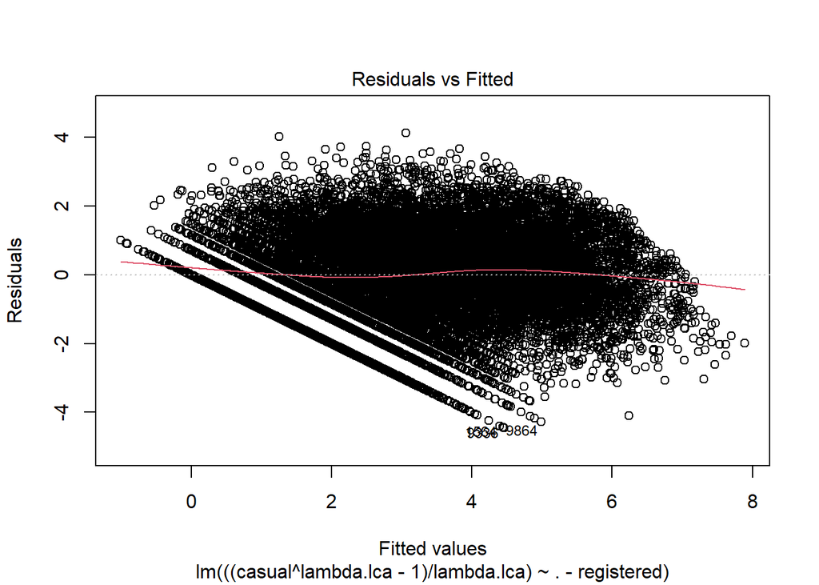

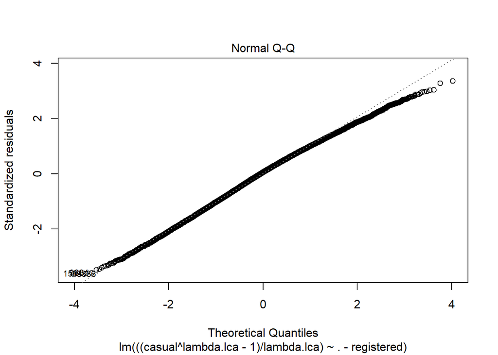

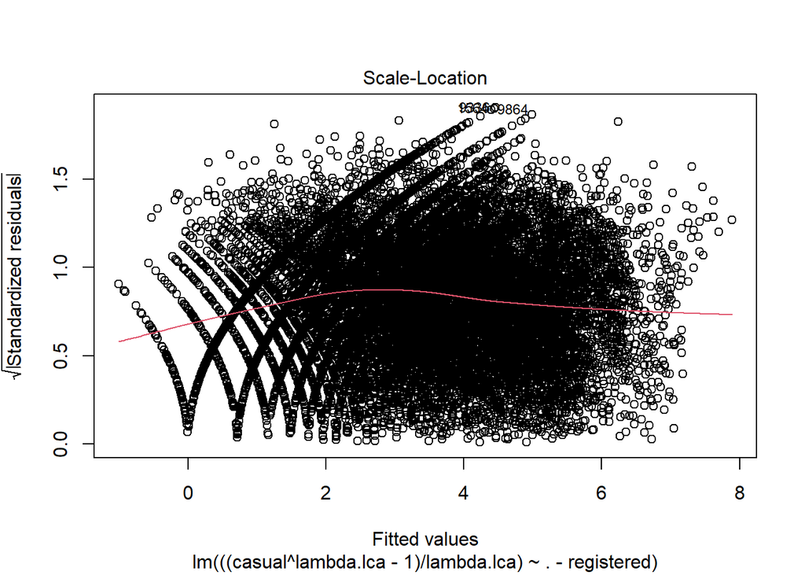

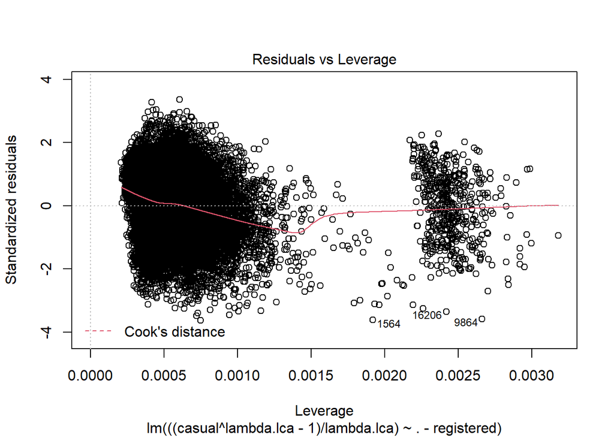

```r
plot(model.lca)
```

### Linear, Casual, temp

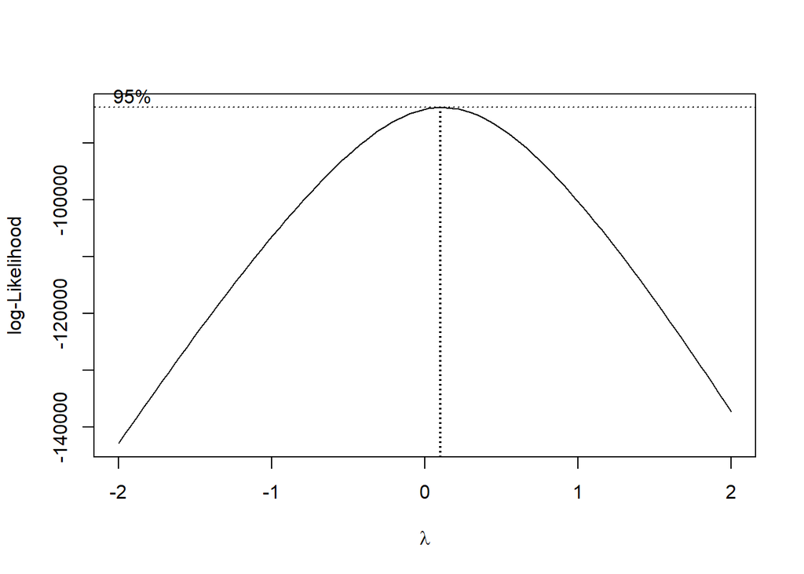

```r
x.lt <- subset(df, select = - c(season,atemp))
x.lt$casual <- x.lt$casual+1
x.lt$registered <- x.lt$registered+1

bc.lct<-boxcox(casual ~. - registered,data = x.lt )
```

```r
lambda.lct <- bc.lct$x[which.max(bc.lct$y)]
model.lct <- lm(((casual^lambda.lct-1)/lambda.lct) ~ . - registered, data = x.lt)

summary(model.lct)
```

```
##
## Call:
## lm(formula = ((casual^lambda.lct - 1)/lambda.lct) ~ . - registered,
##     data = x.lt)
##
## Residuals:
##     Min      1Q  Median      3Q     Max
## -4.5153 -0.8348  0.0630  0.8811  4.1755
##
## Coefficients:
##              Estimate Std. Error t value Pr(>|t|)
## (Intercept)  1.534930   0.058755  26.124  < 2e-16 ***
## yr           0.299548   0.018814  15.922  < 2e-16 ***
## mnth         0.035450   0.002840  12.481  < 2e-16 ***
## hr           0.094369   0.001432  65.890  < 2e-16 ***
## holiday     -0.337073   0.058128  -5.799 6.79e-09 ***
## weekday      0.012203   0.004695   2.599  0.00935 **
## workingday  -0.963647   0.020824 -46.276  < 2e-16 ***
## weathersit   0.004526   0.016536   0.274  0.78429
## temp         5.016763   0.050558  99.228  < 2e-16 ***
## hum         -2.584978   0.059757 -43.258  < 2e-16 ***
## windspeed    0.024932   0.081521   0.306  0.75973
## ---
## Signif. codes:  0 '***' 0.001 '**' 0.01 '*' 0.05 '.' 0.1 ' ' 1
##
## Residual standard error: 1.233 on 17368 degrees of freedom
## Multiple R-squared:  0.5987, Adjusted R-squared:  0.5985
## F-statistic:  2592 on 10 and 17368 DF,  p-value: < 2.2e-16
```

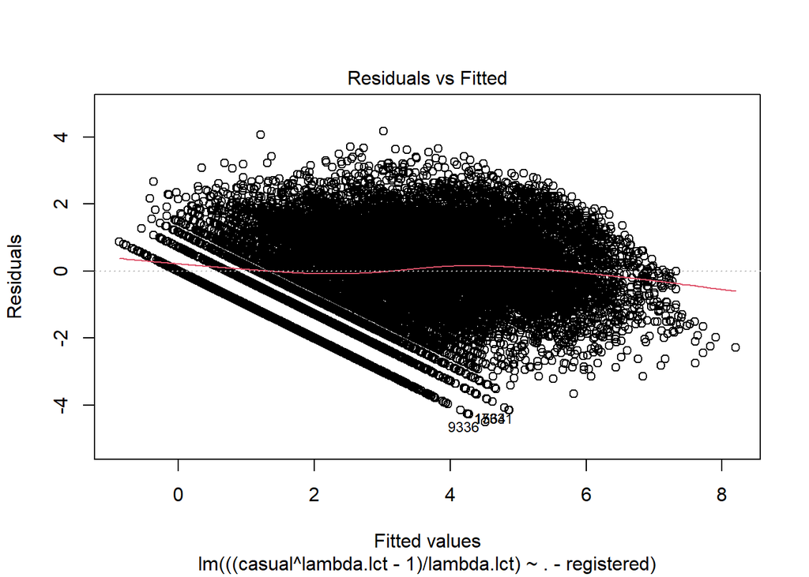

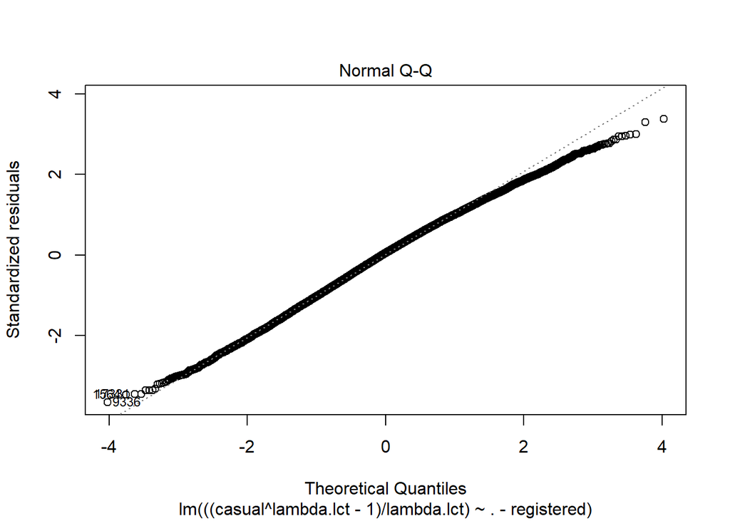

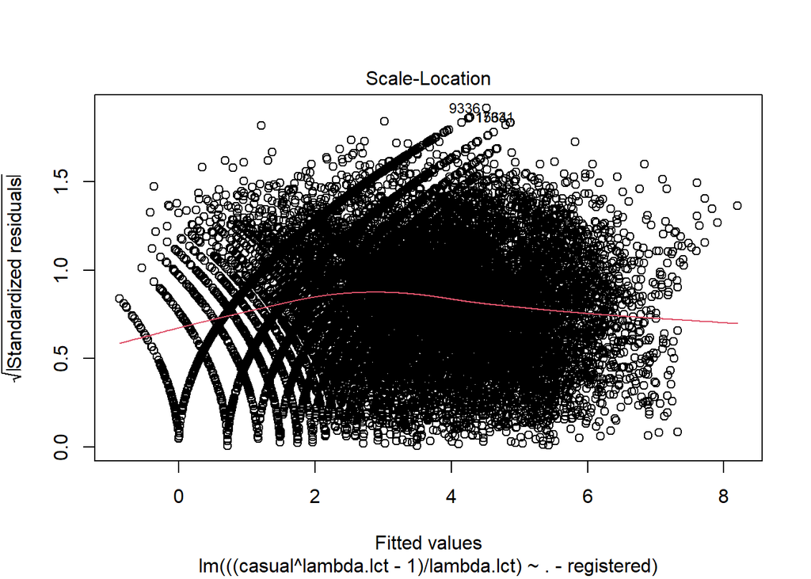

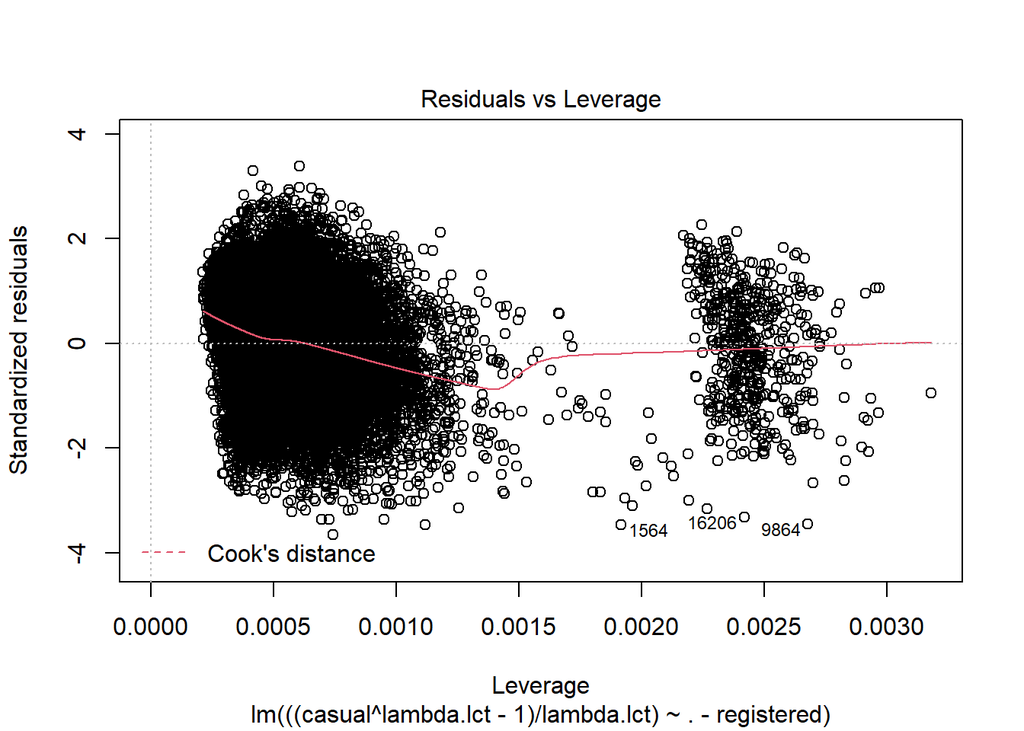

```r
plot(model.lct)
```

### Quadratic, Casual, atemp

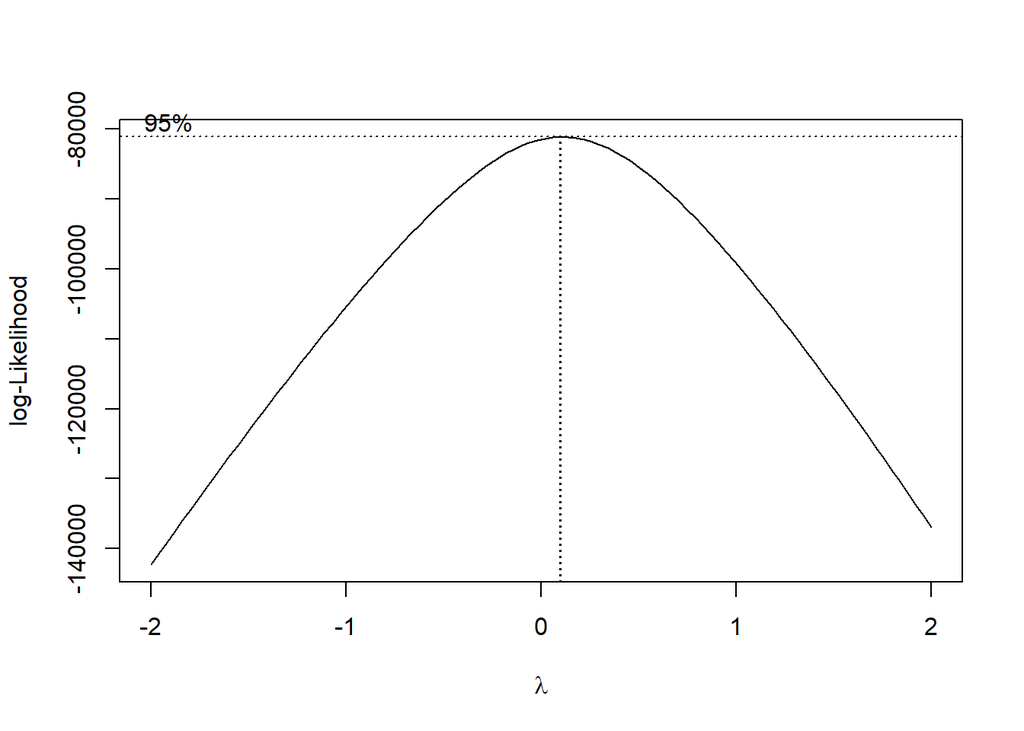

```r
x.qa <- subset(df, select = - c(season,temp))
x.qa$casual <- x.qa$casual+1
x.qa$registered <- x.qa$registered+1
x.qa$mnth2 <- x.qa$mnth^2
x.qa$hr2 <- x.qa$hr^2
x.qa$weekday2 <- x.qa$weekday^2
x.qa$weathersit2 <- x.qa$weathersit^2
x.qa$atemp2 <- x.qa$atemp^2
x.qa$hum2 <- x.qa$hum^2
x.qa$windspeed2 <- x.qa$windspeed^2

bc.qca<-boxcox(casual ~. - registered,data = x.qa )
```

```r
lambda.qca <- bc.qca$x[which.max(bc.qca$y)]
model.qca <- lm(((casual^lambda.qca-1)/lambda.qca) ~ . - registered, data = x.qa)

summary(model.qca)
```

```
##
## Call:
## lm(formula = ((casual^lambda.qca - 1)/lambda.qca) ~ . - registered,
##     data = x.qa)
##
## Residuals:
##     Min      1Q  Median      3Q     Max
## -4.2628 -0.6345  0.0864  0.6851  4.7887
##
## Coefficients:
##               Estimate Std. Error t value Pr(>|t|)
## (Intercept) -2.7031096  0.1166333 -23.176  < 2e-16 ***
## yr           0.2987294  0.0163347  18.288  < 2e-16 ***
## mnth         0.1745436  0.0186063   9.381  < 2e-16 ***
## hr           0.4244173  0.0048783  87.000  < 2e-16 ***
## holiday      0.1507912  0.0597641   2.523   0.0116 *
## weekday     -0.4253875  0.0350880 -12.123  < 2e-16 ***
## workingday  -0.4359713  0.0446172  -9.771  < 2e-16 ***
## weathersit   0.7900388  0.0804459   9.821  < 2e-16 ***
## atemp       10.7103119  0.2810788  38.104  < 2e-16 ***
## hum          0.6256131  0.2633012   2.376   0.0175 *
## windspeed    1.1398406  0.1768999   6.443 1.20e-10 ***
## mnth2       -0.0115607  0.0013501  -8.563  < 2e-16 ***
## hr2         -0.0139316  0.0001986 -70.137  < 2e-16 ***
## weekday2     0.0739773  0.0057976  12.760  < 2e-16 ***
## weathersit2 -0.2468745  0.0219064 -11.269  < 2e-16 ***
## atemp2      -6.3829658  0.2745912 -23.245  < 2e-16 ***
## hum2        -2.1783838  0.2125857 -10.247  < 2e-16 ***
## windspeed2  -2.4734663  0.3611215  -6.849 7.66e-12 ***
## ---
## Signif. codes:  0 '***' 0.001 '**' 0.01 '*' 0.05 '.' 0.1 ' ' 1
##
## Residual standard error: 1.062 on 17361 degrees of freedom
## Multiple R-squared:  0.7024, Adjusted R-squared:  0.7021
## F-statistic:  2411 on 17 and 17361 DF,  p-value: < 2.2e-16
```

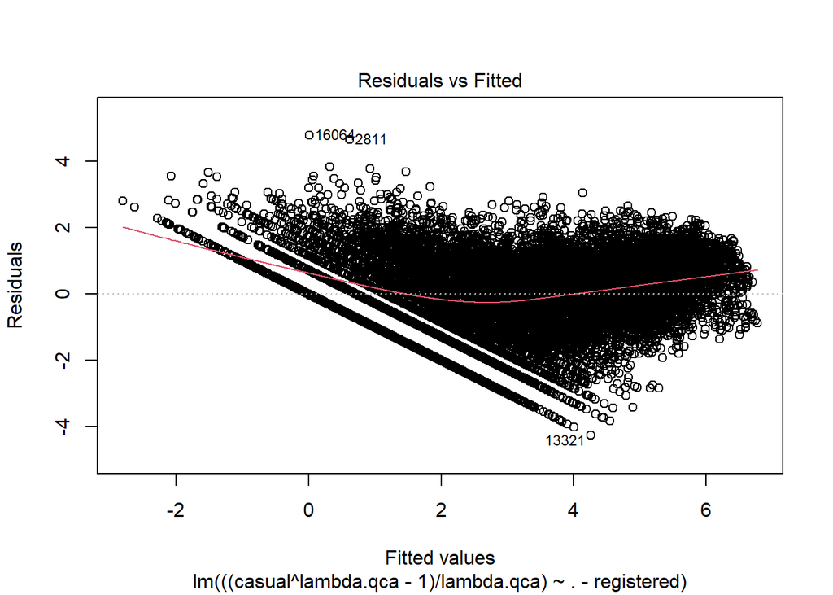

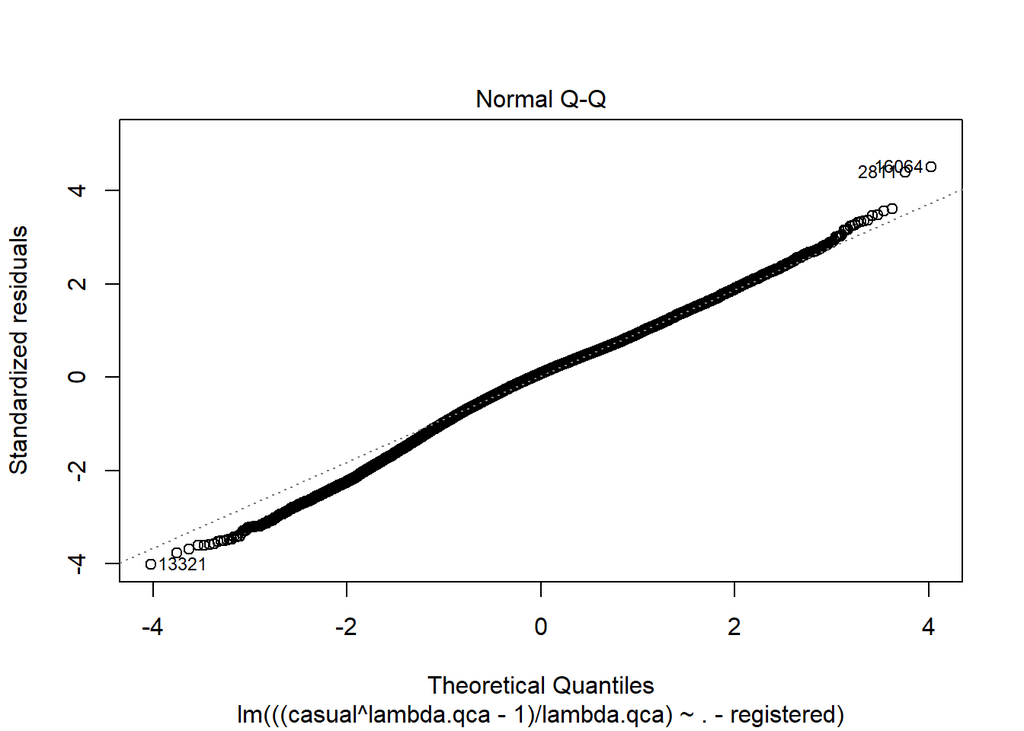

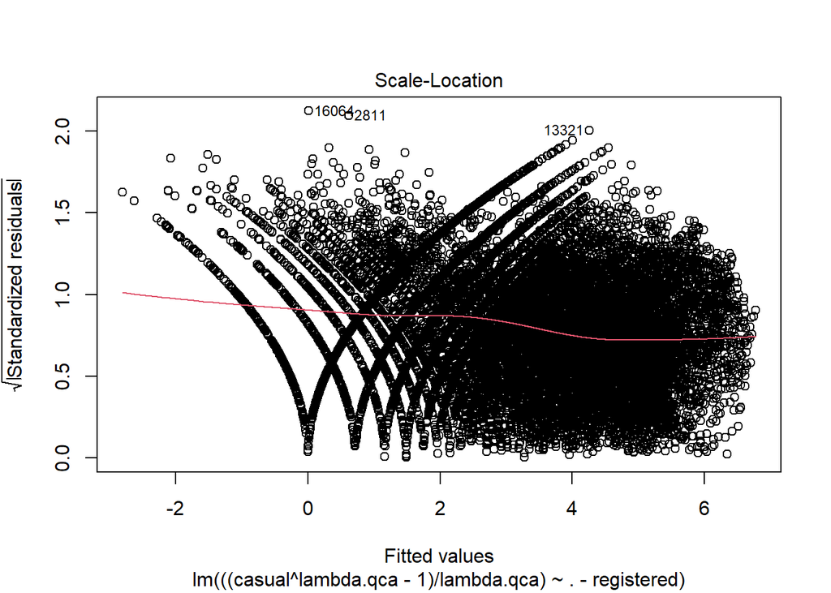

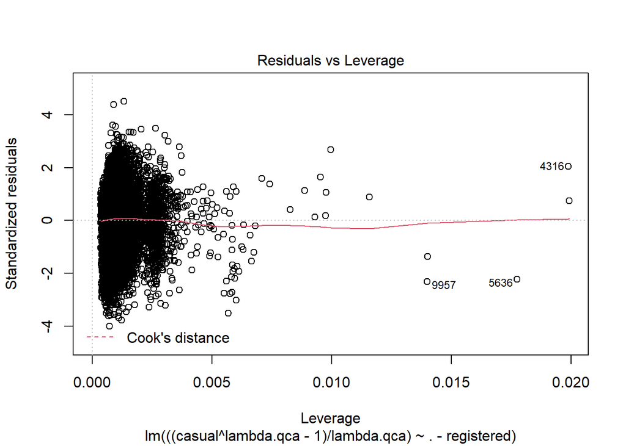

```r
plot(model.qca)
```

### Quadratic, Casual, temp

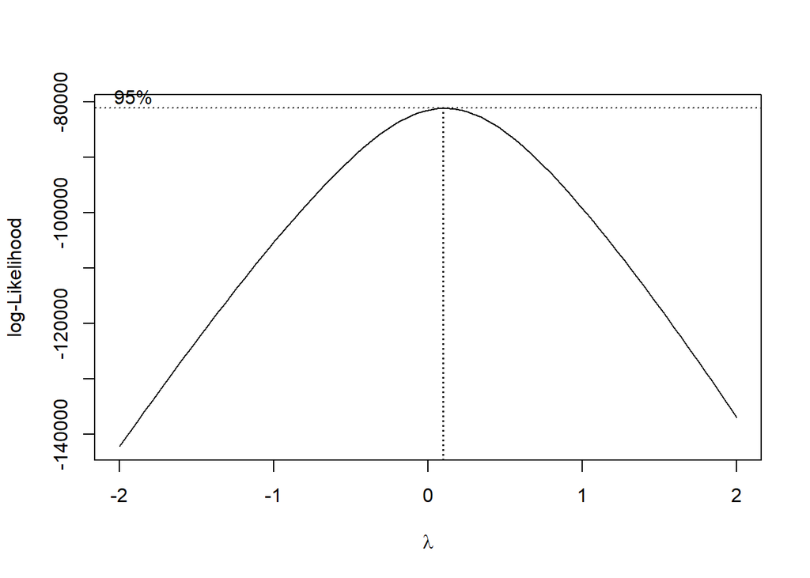

```r
x.qt <- subset(df, select = - c(season,atemp))
x.qt$casual <- x.qt$casual+1
x.qt$registered <- x.qt$registered+1
x.qt$mnth2 <- x.qt$mnth^2
x.qt$hr2 <- x.qt$hr^2
x.qt$weekday2 <- x.qt$weekday^2
x.qt$weathersit2 <- x.qt$weathersit^2
x.qt$temp2 <- x.qt$temp^2
x.qt$hum2 <- x.qt$hum^2
x.qt$windspeed2 <- x.qt$windspeed^2

bc.qct<-boxcox(casual ~. - registered,data = x.qt )
```

```r
lambda.qct <- bc.qct$x[which.max(bc.qct$y)]
model.qct <- lm(((casual^lambda.qct-1)/lambda.qct) ~ . - registered, data = x.qt)

summary(model.qct)
```

```
##
## Call:
## lm(formula = ((casual^lambda.qct - 1)/lambda.qct) ~ . - registered,
##     data = x.qt)
##
## Residuals:
##     Min      1Q  Median      3Q     Max
## -4.2823 -0.6279  0.0907  0.6868  4.7835
##
## Coefficients:
##               Estimate Std. Error t value Pr(>|t|)
## (Intercept) -2.4417913  0.1121827 -21.766  < 2e-16 ***
## yr           0.2859821  0.0163646  17.476  < 2e-16 ***
## mnth         0.1120013  0.0194809   5.749 9.11e-09 ***
## hr           0.4250316  0.0048795  87.106  < 2e-16 ***
## holiday      0.1209391  0.0597791   2.023 0.043078 *
## weekday     -0.4287063  0.0350932 -12.216  < 2e-16 ***
## workingday  -0.4405024  0.0446204  -9.872  < 2e-16 ***
## weathersit   0.7667158  0.0804784   9.527  < 2e-16 ***
## temp        10.2706555  0.2546352  40.335  < 2e-16 ***
## hum          0.8863357  0.2625390   3.376 0.000737 ***
## windspeed    0.5858521  0.1767235   3.315 0.000918 ***
## mnth2       -0.0070500  0.0014114  -4.995 5.94e-07 ***
## hr2         -0.0139737  0.0001987 -70.328  < 2e-16 ***
## weekday2     0.0741906  0.0057982  12.795  < 2e-16 ***
## weathersit2 -0.2413600  0.0219154 -11.013  < 2e-16 ***
## temp2       -5.9143544  0.2295750 -25.762  < 2e-16 ***
## hum2        -2.3976485  0.2114640 -11.338  < 2e-16 ***
## windspeed2  -2.2078173  0.3611390  -6.113 9.96e-10 ***
## ---
## Signif. codes:  0 '***' 0.001 '**' 0.01 '*' 0.05 '.' 0.1 ' ' 1
##
## Residual standard error: 1.062 on 17361 degrees of freedom
## Multiple R-squared:  0.7023, Adjusted R-squared:  0.702
## F-statistic:  2410 on 17 and 17361 DF,  p-value: < 2.2e-16
```

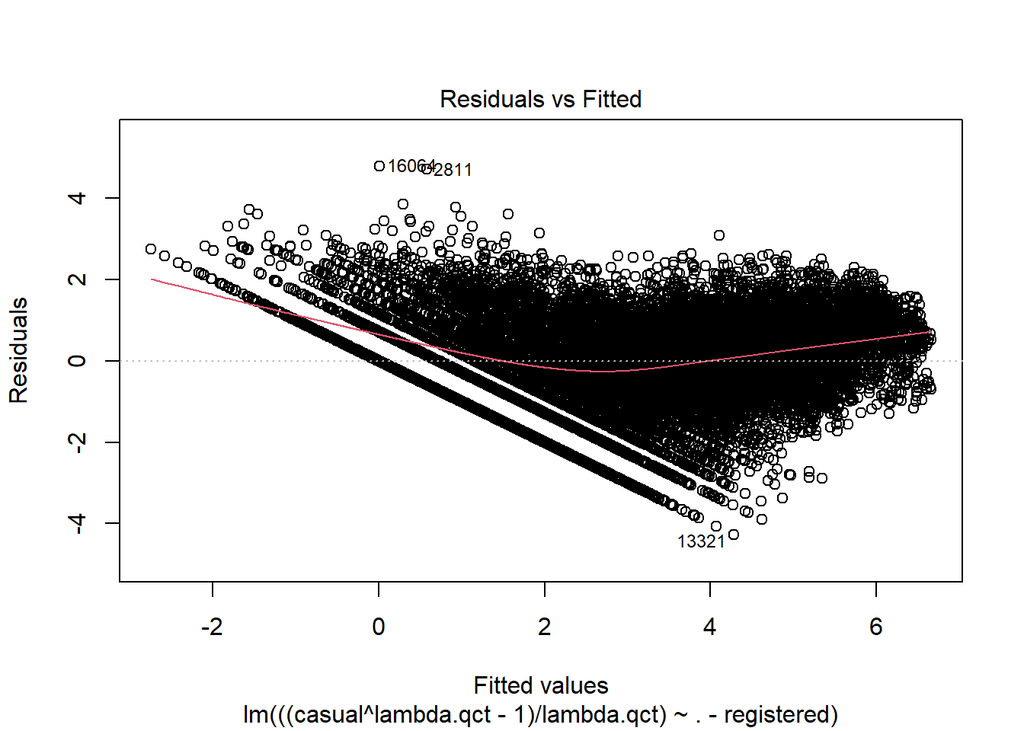

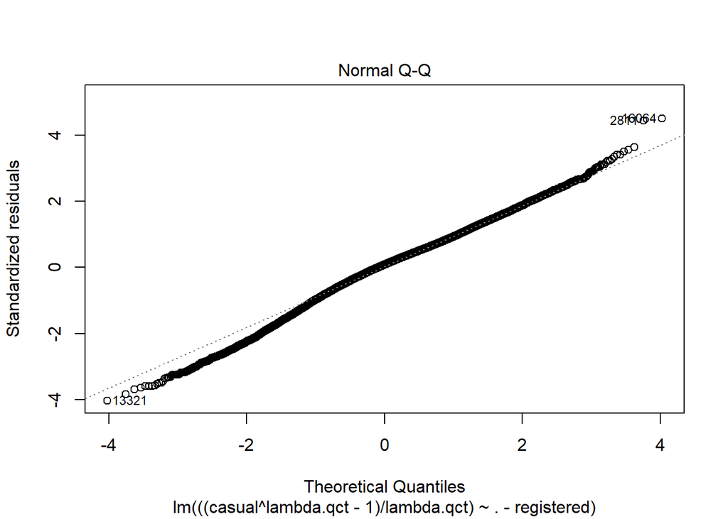

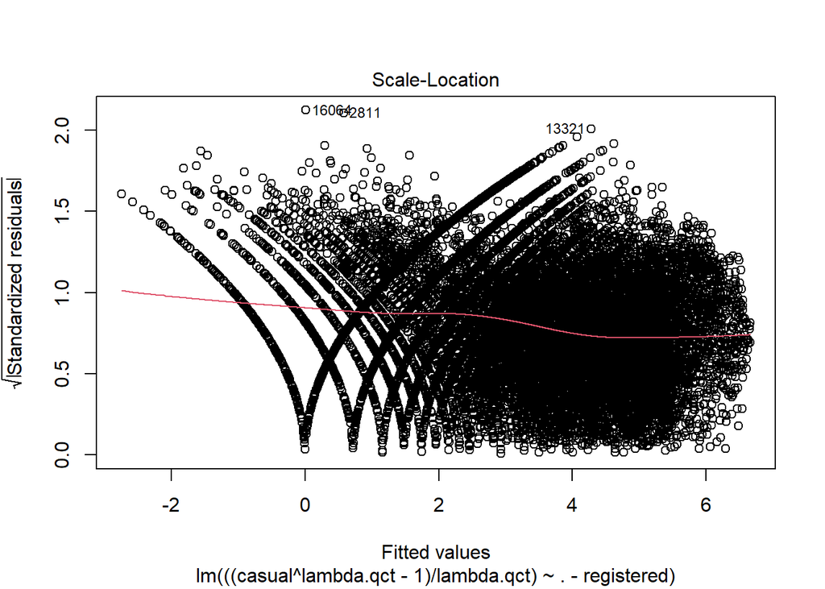

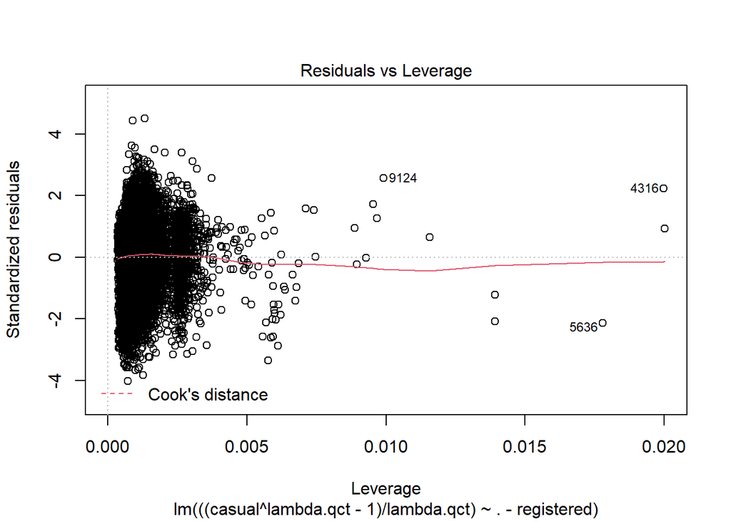

```r
plot(model.qct)
```